# Community characteristics

Justin Sulik

2022-10-03

```r
library(tidyverse)
library(lubridate)
library(readxl)
library(lubridate)
library(janitor)
library(cowplot)
library(pander)

theme_set(theme_minimal() +
            theme(panel.grid = element_blank()))

color_palette <- wesanderson::wes_palette(name="Zissou1")
colors_2 <- c("#DD3C51", "#313657")
focal_countries <- c("ARG", "DEU")
```

In this document, we provide further information on characteristics of our focal communities—ambivalent complementary medicine (CM) users—for our project “Personalizing social media strategies to address rising vaccine-ambivalence in Complementary Medicine users with chronic conditions”.

First, we present an outline of the relevant philosophical/cognitive frameworks that may make some ambivalent CM users sceptical of science-based evidence. Second, we provide a broad overview of some publicly accessible datasets of vaccine uptake that we have explored to inform our choice of topic and communities.

# Philosophical and Cognitive Frameworks

We highlighted in the project proposal how CM users’ health decision making reflects, in part, their unique beliefs and perspectives. We also indicated that these cognitive or philosophical frameworks these beliefs are based in might contribute to vaccine hesitance. Here we briefly describe these frameworks across three core concepts: Experience, Interpretation, Action.

**Experience:** CM users score higher on openness to experience; report more mystical/schizotypal experiences; and are more likely to believe that knowledge is grounded in spiritual experiences (Browne et al., 2015; Lindeman et al., 2011; Thomson et al., 2014; Willard & Norenzayan, 2017). These traits are associated with acceptance of new ideas, unlike the cognitive rigidity more typical of right-wing or religious opponents of science (Costello et al., In press). However, they are associated with antipathy to authority and with reliance on intuition, both of which are barriers to pro-vaccine arguments based on scientific expertise.

**Interpretation:** CM users draw on unique explanatory frameworks Lindeman et al. (2022). They often interpret their experiences or the world through the lenses of holism or mind-body dualism (Willard & Norenzayan, 2017). They sometimes blur distinctions between ontological categories, e.g. between health/biology and energy/physics (Lindeman et al., 2011). They may interpret events in fundamentally unscientific ways (e.g., in magical or anecdotal term, Bryden et al., 2018).

**Action:** CM users have a Do-It-Yourself attitude to healthcare, valuing their own agency in making health decisions (Attwell et al., 2018). They score high on ‘internal health locus of control’ (i-HLOC, Schützler & Witt, 2014), the belief that individuals control their own health (vs control residing with externals such as God or medical experts). This is intriguing because high i-HLOC is generally associated with pro-vaccine attitudes (Amit Aharon et al., 2018). Also relevant to vaccination is that people’s reasons for accessing CM include boosting their immune system (Attwell et al., 2018; Mulder et al., 2022).

These philosophical and cognitive frameworks are not merely descriptive, but actually constitute the common ground between CM and vaccine hesitancy (Browne et al., 2015) and allow CM and vaccine hesitancy to amplify each other (Attwell et al., 2018). However, they also suggest features that potentially form the basis of pro-vaccine arguments, such as taking control of boosting one’s own immune system, being open to interpreting their own and others’ experiences, and valuing peer advice.

# Vaccine uptake

The following is a broad overview of some public datasets including vaccination, COVID and CM. As these datasets are aggregated per country, we do not calculate statistics or address significant differences between our two focal countries (Germany/DEU and Argentina/ARG). Rather, we just present trends for illustrative purposes.

## Childhood vaccines (World Health Organization)

We explore data for two of the most common childhood vaccines—measles and diphtheria/tetanus/pertussis (DTP)—as well as a more recent, controversial vaccine for adolescents (Human Papillomavirus, HPV).

Data sources:

- DTP: [https://immunizationdata.who.int/pages/coverage/dtp.html](https://immunizationdata.who.int/pages/coverage/dtp.html?GROUP=Countries&ANTIGEN=DTPCV3&YEAR=&CODE=)
- Measles: [https://immunizationdata.who.int/pages/coverage/MCV.html](https://immunizationdata.who.int/pages/coverage/MCV.html?GROUP=Countries&ANTIGEN=&YEAR=&CODE=)
- HPV: https://immunizationdata.who.int/pages/coverage/dtp.html

Data dashboard: https://immunizationdata.who.int

Argentina has experienced a decline in some routine childhood vaccinations over the last 5 years of the data (e.g., DTP and Measles), in the former case falling below the global mean. Though above the global mean, general uptake for HPV vaccines is low. Our focus on routine vaccines will include the parents making the medical decisions for these children.

```r
dtp3 <- read_excel("../data/Diphtheria Tetanus Toxoid and Pertussis (DTP) vaccination coverage 2022-03-010 14-12 UTC.xlsx",
    sheet = "Sheet1") %>%
  clean_names %>%
  mutate(focal = code %in% focal_countries) %>%
  filter(coverage_category=="WUENIC",
         antigen=="DTPCV3")

hpv <- read_excel("../data/wuenic2021rev_hpv-estimates.xlsx",
    sheet = "hpv-estimates") %>%
  clean_names %>%
  mutate(focal = iso_code %in% focal_countries) %>%
  filter(vaccine_code == "PRHPV1_F")

measles <- read_excel("../data/Measles vaccination coverage 2022-07-010 11-57 UTC.xlsx",
                      sheet = "Sheet1") %>%
  clean_names %>%
  mutate(focal = code %in% focal_countries) %>%
  filter(antigen == "MCV2",
         coverage_category=="WUENIC")

flu <- read_excel("../data/Influenza vaccination coverage 2022-07-010 11-19 UTC.xlsx",
                  sheet="Sheet1") %>%
  clean_names %>%
  mutate(focal = code %in% focal_countries) %>%
  filter(antigen %in% c("FLU_ALL", "FLU_ELDERLY",
                        "FLU_CHRONIC_ALL"))
```

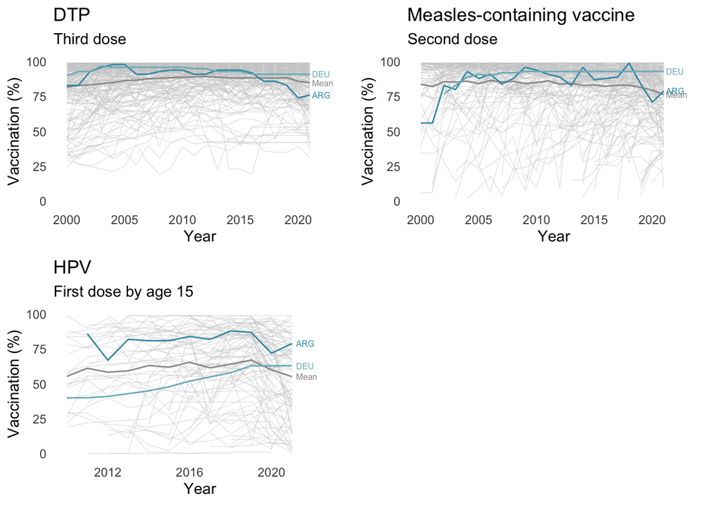

```r
who_dtp3 <- dtp3 %>%
  ggplot(aes(x=year,
             y=coverage)) +
  geom_line(data=dtp3 %>%
              filter(!focal),
            aes(group=code),
            color="grey80",
            alpha=0.6,
            size=0.2) +
  geom_line(data=dtp3 %>%
              group_by(year) %>%
              summarise(coverage = mean(coverage)),
            color="grey60") +
  geom_line(data=dtp3 %>%
              filter(focal),
            aes(group=code,
                color=code)) +
  geom_text(data = dtp3 %>%
              filter(year==2021) %>%
              summarise(coverage = mean(coverage)),
           label="Mean",
           color="Grey60",
           x=2021.2,
           hjust=0,
            size=6/.pt) +
  geom_text(data = dtp3 %>%
              filter(focal, year==2021),
            aes(label=code,
                color=code),
            x=2021.2,
            hjust=0,
            size=6/.pt) +
  scale_color_manual(values=color_palette) +
  labs(title="DTP",
       subtitle="Third dose",
       y="Vaccination (%)",
       x="Year") +
  guides(color="none") +
  coord_cartesian(ylim=c(0,100),
                  xlim=c(2000, 2023))

who_hpv <- hpv %>%
  ggplot(aes(x=year,
             y=coverage)) +
  geom_line(data=hpv %>%
              filter(!focal),
            aes(group=iso_code),
            color="grey80",
            alpha=0.6,
            size=0.2) +
  geom_line(data=hpv %>%
              group_by(year) %>%
              summarise(coverage = mean(coverage)),
            color="grey60") +
  geom_line(data=hpv %>%
              filter(focal),
            aes(group=iso_code,
                color=iso_code)) +
  geom_text(data = hpv %>%
              filter(year==2021) %>%
              summarise(coverage = mean(coverage)),
           label="Mean",
           color="Grey60",
           x=2021.2,
           hjust=0,
           size=6/.pt) +
  geom_text(data = hpv %>%
              filter(focal, year==2021),
            aes(label=iso_code,
                color=iso_code),
            x=2021.2,
            hjust=0,
            size=6/.pt) +
  scale_color_manual(values=color_palette) +
  guides(color="none") +
  coord_cartesian(ylim=c(0,100),
                  xlim=c(2010, 2023)) +
  labs(title="HPV",
       subtitle="First dose by age 15",
       y="Vaccination (%)",
       x="Year")

who_measles <- measles %>%
  ggplot(aes(x=year,
             y=coverage)) +
  geom_line(data=measles %>%
              filter(!focal),
            aes(group=code),
            color="grey80",
            alpha=0.6,
            size=0.2) +
  geom_line(data=measles %>%
              group_by(year) %>%
              summarise(coverage = mean(coverage, na.rm=T)),
            color="grey60") +
  geom_line(data=measles %>%
              filter(focal),
            aes(group=code,
                color=code)) +
  geom_text(data = measles %>%
              filter(year==2021) %>%
              summarise(coverage = mean(coverage, na.rm=T)),
           label="Mean",
           color="Grey60",
           x=2021.2,
           hjust=0,
           size=6/.pt) +
  geom_text(data = measles %>%
              filter(focal, year==2021),
            aes(label=code,
                color=code),
            x=2021.2,
            hjust=0,
            size=6/.pt) +
  scale_color_manual(values=color_palette) +
  labs(title="Measles-containing vaccine",
       subtitle="Second dose",
       y="Vaccination (%)",
       x="Year") +
  guides(color="none") +
  coord_cartesian(ylim=c(0,100),
                  xlim=c(2000, 2023))

plot_grid(who_dtp3, who_measles, who_hpv,
          ncol=2)
```

## Flu vaccinations for 65+ (OECD)

Data source: https://www.oecd-ilibrary.org/social-issues-migration-health/influenza-vaccination-rates/indicator/english_e452582e-en

Data dashboard: https://doi.org/10.1787/e452582e-en

*Note:* This dataset does not include Argentina.

Description from the above dashboard: “Influenza is a common infectious disease that affects many people. Most people with influenza recover quickly, but elderly people and those with chronic medical conditions are at higher risk of complications and even death. Influenza vaccination rate refers to the number of people aged 65 and older who have received an annual influenza vaccination, divided by the total number of people over 65 years of age. This indicator is measured as a percentage of the population aged 65 and older who have received an annual influenza vaccine. The data come from administrative sources or surveys, depending on the country.”

Germany suffered a drop in flu vaccination rates around 2013, dropping below the mean of this dataset (which is not the global mean, as this dataset just reflects OECD countries). It has remained below that mean ever since. This is one reason we focus on routine vaccinations in our project.

```r
flu <- read_csv("../data/DP_LIVE_06102022175420687.csv") %>%
  clean_names
```

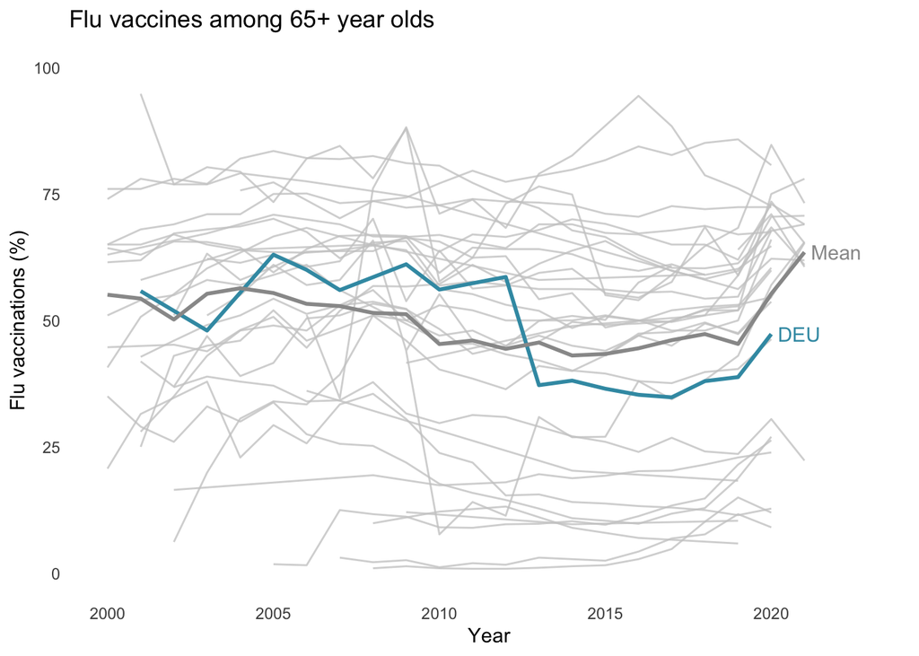

```r
flu %>%
  ggplot(aes(x=time, y=value)) +
  geom_line(data = flu %>%
              filter(location != "DEU"),
            aes(group = location),
            color="grey80",
            alpha=0.8) +
  geom_line(data=flu %>%
              filter(location == "DEU"),
            color=color_palette[1],
            size=1) +
  stat_summary(geom="line",
               fun=mean,
               color="grey60",
               size=1) +
  guides(color="false") +
  annotate(geom = "text",
           label = "DEU",
           hjust = 0,
           color = color_palette[1],
           x=2020.2,
           y=flu %>%
             filter(location=="DEU", time==2020) %>%
             pull(value)) +
  annotate(geom = "text",
           label = "Mean",
           hjust = 0,
           color = "grey60",
           x=2021.2,
           y=flu %>%
             filter(time==2021) %>%
             summarise(value = mean(value, na.rm=T)) %>%
             pull(value)) +
  labs(title="Flu vaccines among 65+ year olds",
       x="Year",
       y="Flu vaccinations (%)") +
  coord_cartesian(ylim=c(0, 100),
                  xlim=c(2000, 2023))
```

## Covid vaccinations (Our world in data)

Data source: https://github.com/owid/covid-19-data/tree/master/public/data/vaccinations

Data dashboard: https://ourworldindata.org/covid-vaccinations

A global dataset of COVID vaccination, described as follows at the above dashboard: “Our vaccination dataset uses the most recent official numbers from governments and health ministries worldwide. Population estimates for per-capita metrics are based on the United Nations World Population Prospects. Income groups are based on the World Bank classification.” A more detailed description is available at the above Github link.

Both Germany and Argentina have a higher-than-average rate of COVID-19 vaccination, though uptake in Argentina has been substantially higher than in Germany (Argentina: 83.5% have two doses; Germany: 76.1%). However, to the extent that COVID-19 boosters become like other routine vaccinations (and long COVID becomes another chronic condition), these fall within our scope.

```r
vaccinations_owid <- read_csv("~/Documents/munich/grants/vaccineconfidence/material/data/vaccinations.csv") %>%
  clean_names %>%
  # 5 countries reported more than 100% being partly vaccinated
  # Most are small states, so as this issue isn't critical for
  # this overview, I'm just excluding them
  filter(! iso_code %in% c("ARE", "BRN", "GIB", "QAT", "TKM")) %>%
  group_by(iso_code, date=cut(date, "week")) %>%
  summarise(partly = mean(people_vaccinated_per_hundred, na.rm=T),
            fully = mean(people_fully_vaccinated_per_hundred, na.rm=T),
            boosted = mean(total_boosters_per_hundred, na.rm=T)) %>%
  mutate(date = as.Date(date),
         focal = iso_code %in% focal_countries)
```

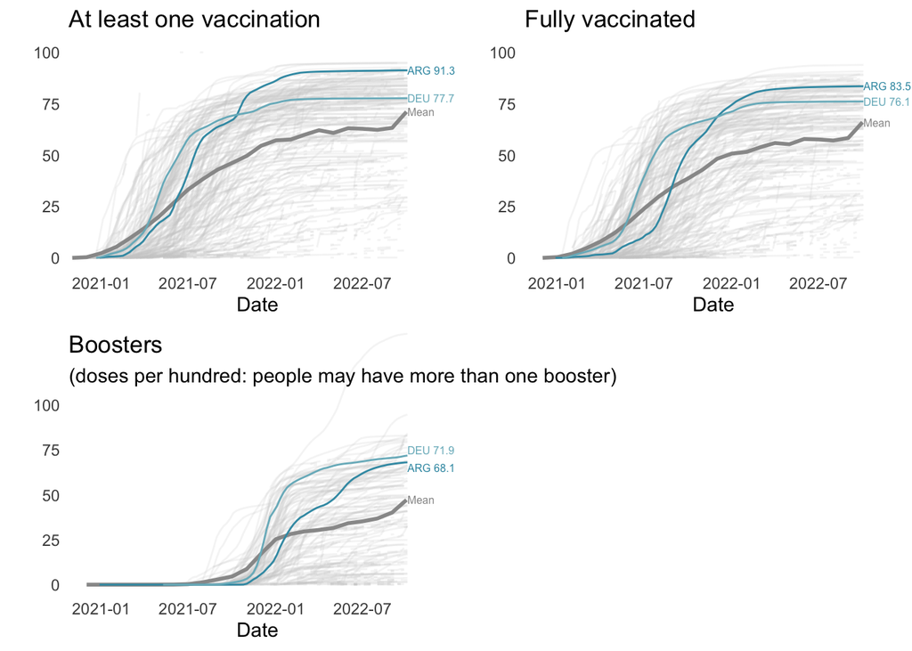

```r
x_lim <- c(min(vaccinations_owid$date), max(vaccinations_owid$date)+45)

covid_partly <- vaccinations_owid %>%
  ggplot(aes(x=date,y=partly)) +
  geom_line(data = vaccinations_owid %>%
              filter(!focal),
            aes(group=iso_code),
            color="grey80",
            alpha=0.2) +
  geom_line(data = vaccinations_owid %>%
              group_by(date = cut(date, "month")) %>%
              summarise(partly =
                          mean(partly, na.rm=T)) %>%
              mutate(date = as.Date(date)),
            color="grey60",
            size=1) +
  geom_line(data = vaccinations_owid %>%
              filter(focal),
            aes(color = iso_code)) +
  annotate(geom="text",
           label="Mean",
           y=vaccinations_owid %>%
             group_by(date = cut(date, "week")) %>%
             summarise(partly =
                  mean(partly, na.rm=T)) %>%
             mutate(date = as.Date(date)) %>%
             filter(date==max(date)) %>%
             pull(partly),
           x=max(vaccinations_owid$date),
           hjust=0,
           color="grey60",
            size=6/.pt) +
  geom_text(data = vaccinations_owid %>%
              filter(focal) %>%
              group_by(iso_code) %>%
              mutate(recent = max(date)) %>%
              filter(date==recent),
            aes(label=paste(iso_code, round(partly, 1), sep=" "),
                color=iso_code),
            hjust=0,
            size=6/.pt) +
  scale_color_manual(values = color_palette) +
  guides(color="none") +
  coord_cartesian(xlim=x_lim,
                  ylim=c(0, 100),
                  clip="off") +
  labs(x="Date",
       title="At least one vaccination",
       y="")

covid_fully <- vaccinations_owid %>%
  ggplot(aes(x=date,y=fully)) +
  geom_line(data = vaccinations_owid %>%
              filter(!focal),
            aes(group=iso_code),
            color="grey80",
            alpha=0.2) +
  geom_line(data = vaccinations_owid %>%
              group_by(date = cut(date, "month")) %>%
              summarise(fully =
                          mean(fully, na.rm=T)) %>%
              mutate(date = as.Date(date)),
            color="grey60",
            size=1) +
  geom_line(data = vaccinations_owid %>%
              filter(focal),
            aes(color = iso_code)) +
  annotate(geom="text",
           label="Mean",
           y=vaccinations_owid %>%
             group_by(date = cut(date, "week")) %>%
             summarise(fully =
                  mean(fully, na.rm=T)) %>%
             mutate(date = as.Date(date)) %>%
             filter(date==max(date)) %>%
             pull(fully),
           x=max(vaccinations_owid$date),
           hjust=0,
           color="grey60",
            size=6/.pt) +
  geom_text(data = vaccinations_owid %>%
              filter(focal) %>%
              group_by(iso_code) %>%
              mutate(recent = max(date)) %>%
              filter(date==recent),
            aes(label=paste(iso_code, round(fully,1), sep=" "),
                color=iso_code),
            hjust=0,
            size=6/.pt) +
  scale_color_manual(values = color_palette) +
  guides(color="none") +
  coord_cartesian(xlim=x_lim,
                  ylim=c(0, 100),
                  clip="off") +
  labs(x="Date",
       title="Fully vaccinated",
       y="")

covid_boosters <- vaccinations_owid %>%
  ggplot(aes(x=date, y=boosted)) +
  geom_line(data = vaccinations_owid %>%
              filter(!focal),
            aes(group=iso_code),
            color="grey80",
            alpha=0.2) +
  geom_line(data = vaccinations_owid %>%
              group_by(date = cut(date, "month")) %>%
              summarise(boosted =
                          mean(boosted, na.rm=T)) %>%
              mutate(date = as.Date(date)),
            color="grey60",
            size=1) +
  geom_line(data = vaccinations_owid %>%
              filter(focal),
            aes(color = iso_code)) +
  annotate(geom="text",
           label="Mean",
           y=vaccinations_owid %>%
             group_by(date = cut(date, "week")) %>%
             summarise(boosted =
                  mean(boosted, na.rm=T)) %>%
             mutate(date = as.Date(date)) %>%
             filter(date==max(date)) %>%
             pull(boosted),
           x=max(vaccinations_owid$date),
           hjust=0,
           color="grey60",
          size=6/.pt) +
  geom_text(data = vaccinations_owid %>%
              filter(focal) %>%
              group_by(iso_code) %>%
              mutate(jit = ifelse(iso_code == "DEU", 3, -3),
                     recent = max(date)) %>%
              filter(date==recent),
            aes(label=paste(iso_code, round(boosted,1), sep=" "),
                color=iso_code,
                y=boosted+jit),
            hjust=0,
            size=6/.pt) +
  scale_color_manual(values = color_palette) +
  guides(color="none") +
  coord_cartesian(xlim=x_lim,
                  ylim=c(0, 100),
                  clip="off") +
  labs(x="Date",
       title="Boosters",
       subtitle="(doses per hundred: people may have more than one booster)",
       y="")

plot_grid(covid_partly, covid_fully, covid_boosters)
```

## Covid and Complementary Medicine (MIT/Data For Good)

Data source: https://covidsurvey.mit.edu/api.html

A large dataset (~1 million people) collected over 19 fortnightly waves. Wave 1 was July 6th to 20th, 2020, with the final wave in March 2021. The survey asked about a range of preventative behaviors, trust in sources of info, attitudes to COVID vaccination.

```r
fb_data1 <- read_csv("../data/facebook_mit_data1.csv") %>%
  mutate(country = ifelse(country=="DE", "DEU", "ARG"))
fb_data2 <- read_csv("../data/facebook_mit_data2.csv") %>%
  mutate(wave = parse_number(wave)) %>%
  filter(wave < 20) %>%
  mutate(country = ifelse(country=="DE", "DEU", "ARG"))
fb_data4 <- read_csv("../data/facebook_mit_data4.csv") %>%
  mutate(country = ifelse(country=="DE", "DEU", "ARG"))
```

For much of the duration of data collection, COVID vaccines were not yet available, so the survey asked if participants would accept a vaccine once available. In both countries, the number of hesitants (“don’t know”) is comparable—or even larger—than the number of refusers (“no”).

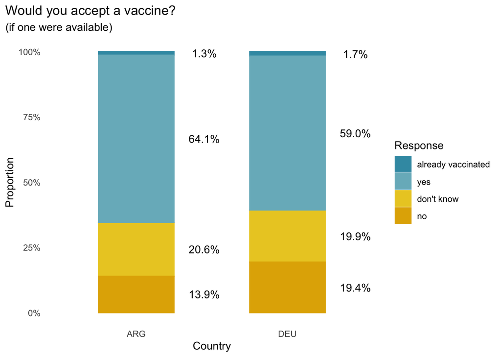

```r
summary_data4 <- fb_data4 %>%
  select(country, starts_with("vaccine_accept")) %>%
  gather(key, var, starts_with("vaccine")) %>%
  mutate(key = str_replace(key, "attept_", "accept-"),
         key = str_replace(key, "_weighted_", "-")) %>%
  separate(key, c("key_", "response"), sep="-") %>%
  mutate(response = case_when(
    str_detect(response, "i_") ~ "already vaccinated",
    str_detect(response, "don_") ~ "don't know",
    TRUE ~ response
  )) %>%
  mutate(var = round(var, 3),
         response = fct_relevel(response,
                                levels=c("already vaccinated", "yes", "don't know", "no"))) %>%
  select(-key_) %>%
  arrange(country, response) %>%
  group_by(country) %>%
  mutate(cumulative = 1-cumsum(var))

fb_data4 %>%
  select(country, starts_with("vaccine_accept")) %>%
  gather(key, var, starts_with("vaccine")) %>%
  mutate(key = str_replace(key, "attept_", "accept-"),
         key = str_replace(key, "_weighted_", "-")) %>%
  separate(key, c("key_", "response"), sep="-") %>%
  mutate(response = case_when(
    str_detect(response, "i_") ~ "already vaccinated",
    str_detect(response, "don_") ~ "don't know",
    TRUE ~ response
  )) %>%
  mutate(response = fct_relevel(response,
                                levels=c("already vaccinated",
                                "yes",
                                "don't know",
                                "no"))) %>%
  ggplot(aes(x=country, y=var, color=response,
             fill=response)) +
  geom_bar(stat="identity", width=0.5) +
  geom_text(data=summary_data4,
            aes(y=cumulative+var/2,
                label=scales::percent(var)),
            nudge_x=0.45,
            color="black") +
  scale_color_manual(values = color_palette) +
  scale_fill_manual(values = color_palette) +
  scale_y_continuous(labels = scales::percent) +
  labs(x="Country",
       y="Proportion",
       fill="Response",
       color="Response",
       title="Would you accept a vaccine?",
       subtitle="(if one were available)") +
  theme(plot.title.position = "plot")
```

As the survey data was collected over a number of waves, we can inspect change in vaccination attitudes over time. Although there was some variation over time, the number of hesitants (“don’t know”) was consistently comparable in magnitude to the number of rejecters (“no”).

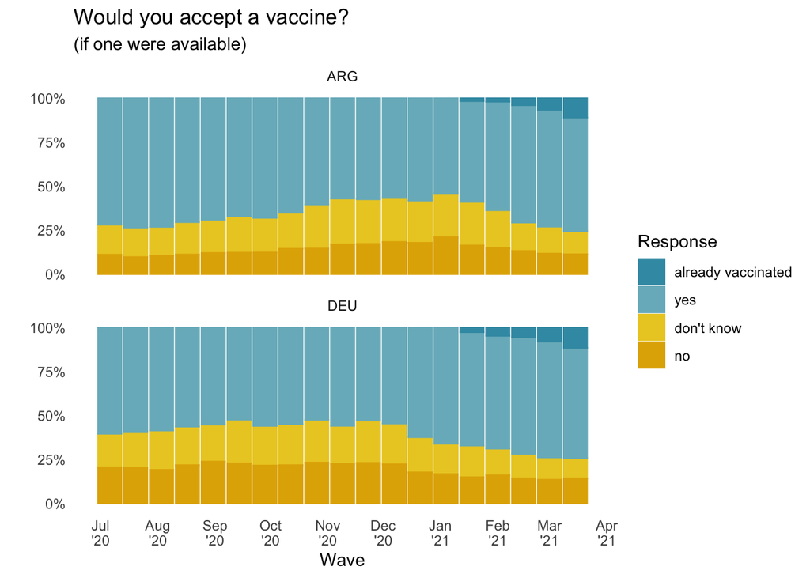

```r
fb_data2 %>%
  mutate(time = ymd("2020-07-06") + 2*weeks(wave-1)) %>%
  select(country, time, starts_with("vaccine_accept")) %>%
  gather(key, var, starts_with("vaccine")) %>%
  mutate(key = str_replace(key, "attept_", "accept-"),
         key = str_replace(key, "_weighted_", "-")) %>%
  separate(key, c("key_", "response"), sep="-") %>%
  mutate(response = case_when(
    str_detect(response, "i_") ~ "already vaccinated",
    str_detect(response, "don_") ~ "don't know",
    TRUE ~ response
  )) %>%
  mutate(response = fct_relevel(response,
                                levels=c("already vaccinated", "yes", "don't know", "no"))) %>%
  ggplot(aes(x=time, y=var, color=response,
             fill=response)) +
  geom_bar(stat="identity") +
  facet_wrap(~country,
             ncol=1) +
  labs(title="Would you accept a vaccine?",
       subtitle="(if one were available)",
       y="",
       x="Wave",
       color="Response",
       fill="Response") +
  scale_color_manual(values = color_palette) +
  scale_fill_manual(values = color_palette) +
  scale_x_date(date_breaks = "1 month",
               date_labels = "%b\n'%y") +
  scale_y_continuous(labels=scales::percent)
```

The following question shifts the focus to who is recommending the vaccines. In both countries, recommendations from local health workers are rated as trusted. Thus, local health workers are included in our dissemination plan and knowledge transfer (WP2).

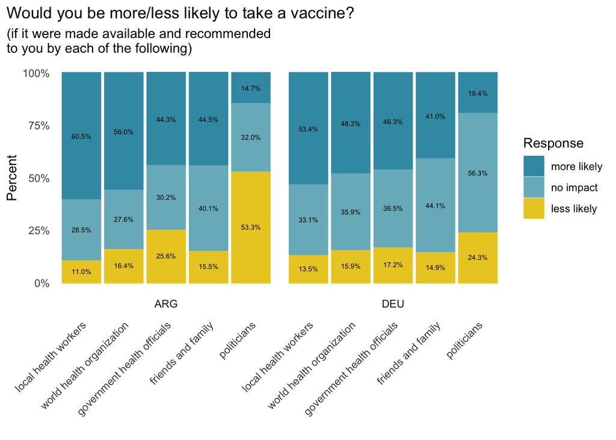

```r
fb_data4 %>%
  select(country, starts_with("future")) %>%
  gather(key, var, starts_with("future")) %>%
  mutate(key = str_replace(key, "recommended_", "recommended-"),
         key = str_replace(key, "_weighted_", "-")) %>%
  separate(key, c("key_", "source", "response"), sep="-") %>%
  mutate(response = str_replace_all(response, "_", " "),
         source = str_replace_all(source, "_", " ")) %>%
  mutate(response = fct_relevel(response,
                                levels=c("more likely", "no impact", "less likely")),
         ordering = -as.numeric(response) + var) %>%
  ggplot(aes(x=fct_reorder(source, ordering),
             y=var, color=response,
             fill=response)) +
  geom_bar(stat="identity") +
  geom_text(aes(label = scales::percent(var)),
            position=position_stack(vjust=0.5),
            color="black",
            size=2) +
  labs(title="Would you be more/less likely to take a vaccine?",
       subtitle="(if it were made available and recommended\nto you by each of the following)",
       y="Percent",
       x="",
       color="Response",
       fill="Response") +
  facet_wrap(~country,
             labeller=label_wrap_gen(25),
             strip.position="bottom") +
  scale_color_manual(values = color_palette) +
  scale_fill_manual(values = color_palette) +
  scale_x_discrete() +
  scale_y_continuous(labels=scales::percent) +
  theme(plot.title.position = "plot",
        axis.text.x = element_text(angle=45,
                                   hjust=1))
```

Aside from vaccines, the survey asked about trusted sources of information. Local health workers are well trusted in both countries, second only to scientists in Argentina.

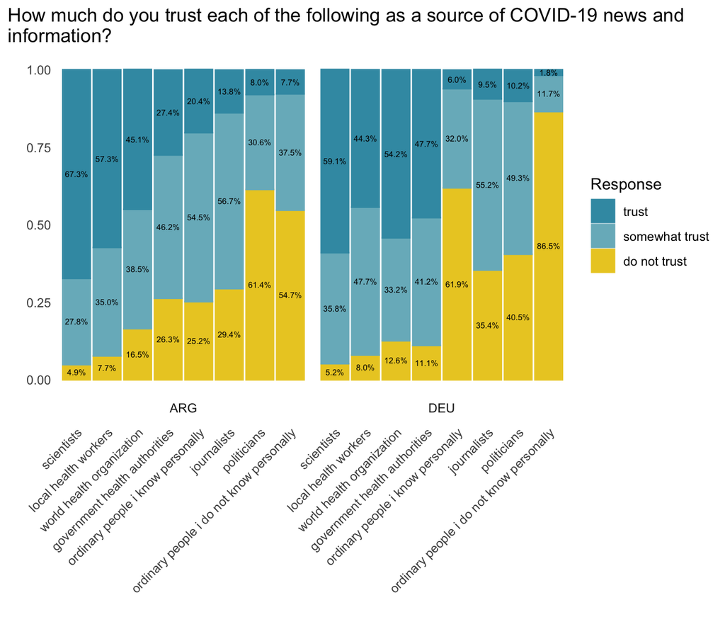

```r
temp <- fb_data4 %>%
  select(country, starts_with("news_sources")) %>%
  gather(key, var, starts_with("news")) %>%
  mutate(key = str_replace(key, "trust_", "trust-"),
         key = str_replace(key, "_weighted_", "-")) %>%
  separate(key, c("key_", "source", "response"), sep="-") %>%
  mutate(response = str_replace_all(response, "_", " "),
         source = str_replace_all(source, "_", " ")) %>%
  mutate(response = fct_relevel(response,
                                levels=c("trust", "somewhat trust", "do not trust")))

ordering <- temp %>%
  filter(country == "ARG", response=="trust") %>%
  arrange(var) %>%
  pull(source)

temp %>%
  mutate(source = fct_relevel(source,
                              levels = rev(ordering))) %>%
  ggplot(aes(x=source, y=var, color=response,
             fill=response)) +
  geom_bar(stat="identity") +
  geom_text(aes(label = scales::percent(var)),
            position=position_stack(vjust=0.5),
            color="black",
            size=2) +
  facet_wrap(~country,
             strip.position="bottom") +
  labs(title=str_wrap("How much do you trust each of the following as a source of COVID-19 news and information?", 80),
       x="",
       y="",
       color="Response",
       fill="Response") +
  scale_color_manual(values = color_palette) +
  scale_fill_manual(values = color_palette) +
  theme(plot.title.position = "plot",
        axis.text.x=element_text(angle=45, hjust=1))
```

Participants were asked what measures they took to prevent COVID infections. The following are the measures most relevant to CM or to vaccination attitudes. *Note:* these do not reflect overall usage of CM, outside of COVID prevention strategies.

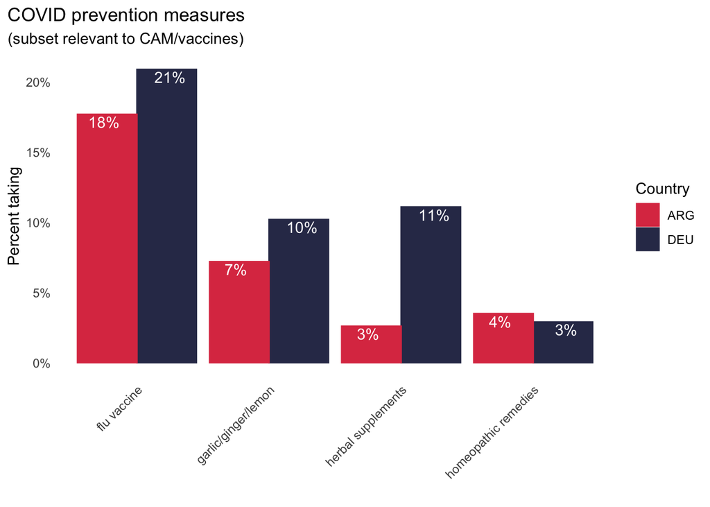

```r
fb_data4 %>%
  select(country, starts_with("measures")) %>%
  gather(key, var, starts_with("measures")) %>%
  mutate(key = str_replace(key, "taken_", "taken-"),
         key = str_replace(key, "_weighted_", "-")) %>%
  separate(key, c("key_", "measure", "response"), sep="-") %>%
  filter(measure %in% c("using_homeopathic_remedies",
                        "taking_herbal_supplements",
                        "getting_the_flu_vaccine",
                        "eating_garlic"),
         response=='yes') %>%
  mutate(measure = str_replace_all(measure, "_", " "),
         measure = case_when(
           grepl("garlic", measure) ~ "garlic/ginger/lemon",
           grepl("herbal", measure) ~ "herbal supplements",
           grepl("homeopathic", measure) ~ "homeopathic remedies",
           TRUE ~ "flu vaccine"
         )) %>%
  ggplot(aes(x=measure, y=var, color=country, fill=country)) +
  geom_bar(stat="identity",
           position="dodge") +
  geom_text(aes(label=scales::percent(round(var, 2))),
            position=position_dodge(width=1),
            vjust=1.2,
            color="white") +
  labs(title="COVID prevention measures",
       subtitle="(subset relevant to CAM/vaccines)",
       x="",
       color="Country",
       fill="Country",
       y="Percent taking") +
  theme(axis.text.x = element_text(angle=45,
                                    hjust=1),
        plot.title.position = "plot") +
  scale_color_manual(values=colors_2) +
  scale_fill_manual(values=colors_2) +
  scale_y_continuous(labels = scales::percent)
```

Consistent with global patterns, in Germany, higher education was associated with greater CM use. In Argentina, this was not the case, at least in the context of COVID prevention measures.

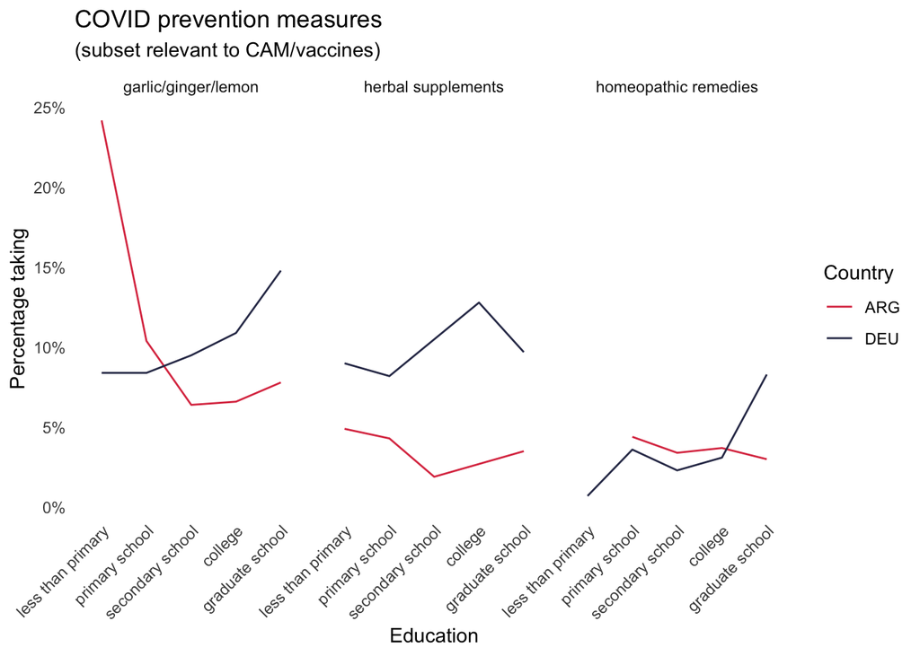

```r
edu_levels <- fb_data1 %>%
  distinct(education) %>%
  mutate(education = str_replace_all(education, "_", " ")) %>%
  pull(education)

fb_data1 %>%
  select(country, education, starts_with("measures")) %>%
  gather(key, var, starts_with("measures")) %>%
  mutate(key = str_replace(key, "taken_", "taken-"),
         key = str_replace(key, "_weighted_", "-")) %>%
  separate(key, c("key_", "measure", "response"), sep="-") %>%
  filter(measure %in% c("using_homeopathic_remedies",
                        "taking_herbal_supplements",
                        #"getting_the_flu_vaccine",
                        "eating_garlic"),
         response=="yes") %>%
  mutate(measure = str_replace_all(measure, "_", " "),
         measure = case_when(
           grepl("garlic", measure) ~ "garlic/ginger/lemon",
           grepl("herbal", measure) ~ "herbal supplements",
           TRUE ~ "homeopathic remedies",
         ),
         education = str_replace_all(education, "_", " "),
         education = factor(education, levels=edu_levels)) %>%
  ggplot(aes(x=education, y=var, color=country,
             group=country)) +
  geom_line() +
  facet_wrap(~measure, labeller=label_wrap_gen(25)) +
  theme(axis.text.x = element_text(angle=45,
                                   hjust=1)) +
  scale_color_manual(values=colors_2) +
  scale_y_continuous(labels=scales::percent) +
  labs(title="COVID prevention measures",
       subtitle="(subset relevant to CAM/vaccines)",
       color="Country",
       y="Percentage taking",
       x="Education")
```

# References

Amit Aharon, A., Nehama, H., Rishpon, S., & Baron-Epel, O. (2018). A path analysis model suggesting the association between health locus of control and compliance with childhood vaccinations. *Human Vaccines & Immunotherapeutics*, *14*(7), 1618–1625.

Attwell, K., Ward, P. R., Meyer, S. B., Rokkas, P. J., & Leask, J. (2018). “Do-it-yourself”: Vaccine rejection and complementary and alternative medicine (CAM). *Social Science & Medicine*, *196*, 106–114.

Browne, M., Thomson, P., Rockloff, M. J., & Pennycook, G. (2015). Going against the herd: Psychological and cultural factors underlying the “vaccination confidence gap.” *PLoS One*, *10*(9), e0132562.

Bryden, G. M., Browne, M., Rockloff, M., & Unsworth, C. (2018). Anti-vaccination and pro-CAM attitudes both reflect magical beliefs about health. *Vaccine*, *36*(9), 1227–1234.

Costello, T. H., Bowes, S. M., Baldwin, M. W., Malka, A., & Tasimi, A. (In press). Revisiting the rigidity-of-the-right hypothesis: A meta-analytic review. *Journal of Personality and Social Psychology*.

Lindeman, M., Svedholm, A. M., Takada, M., Lönnqvist, J.-E., & Verkasalo, M. (2011). Core knowledge confusions among university students. *Science & Education*, *20*(5-6), 439–451.

Lindeman, M., Svedholm-Häkkinen, A. M., & Riekki, T. J. (2022). Searching for the cognitive basis of anti-vaccination attitudes. *Thinking & Reasoning*, 1–26.

Mulder, L. T., Busch, M., Kristoffersen, A. E., Hök Nordberg, J., & Werf, E. T. van der. (2022). Prevalence and predictive factors of complementary medicine use during the first wave of the COVID-19 pandemic of 2020 in the netherlands. *BMC Complementary Medicine and Therapies*, *22*(1), 1–10.

Schützler, L., & Witt, C. M. (2014). Internal health locus of control in users of complementary and alternative medicine: A cross-sectional survey. *BMC Complementary and Alternative Medicine*, *14*, 320.

Thomson, P., Jones, J., Browne, M., & Leslie, S. J. (2014). Psychosocial factors that predict why people use complementary and alternative medicine and continue with its use: A population based study. *Complementary Therapies in Clinical Practice*, *20*(4), 302–310.

Willard, A. K., & Norenzayan, A. (2017). “Spiritual but not religious”: Cognition, schizotypy, and conversion in alternative beliefs. *Cognition*, *165*, 137–146.